# SIG16 ATAC: interaction scoring and classification of accessible peaks

EYW

2026-09-26

```r
suppressPackageStartupMessages({
  library(tidyverse)
  library(patchwork)
  library(RColorBrewer)
  library(ComplexHeatmap)
  library(circlize)
  library(data.table)
})
knitr::opts_chunk$set(echo = TRUE)

source("../../functions/r_custom/plotting_fxns.R")
theme_set(theme_Publication())

set.seed(1)

idr <- 0.05
job.name <- paste0("idr-", idr, "/")

OUT_DIR  <- file.path("../../analysis_outs", "deseq2-merged-reps", job.name)
PLOT_DIR <- file.path("../../analysis_outs", "plots_new", "deseq2-merged-reps", job.name)

# SIG13 gates both branches of the classifier on FDR alone. The |LFC| gate applied to
# both branches below is an ATAC-specific addition (see "Deviations").
padj.int.cutoff  <- 0.05
padj.cond.cutoff <- 0.05
lfc.cutoff       <- log2(1.5)

# SIG13's interaction-class palette, verbatim from
# SIG13/analysis/spca/04_spca_visualization.Rmd. Two of the six labels
# ("additive over saturation", "buffering complete") require the double-dose
# conditions SIG16 does not have, so they never occur here; the names are kept
# so colours stay identical across the two repos.
interaction_palette <- c("#808080", brewer.pal(5, "Dark2"))
names(interaction_palette) <- c("none", "additive over saturation", "buffering",
                                "buffering complete", "synergy negative", "synergy positive")

class_levels <- c("none", "buffering", "synergy negative", "synergy positive")
itxn_levels  <- setdiff(class_levels, "none")
```

# Goal

Score and classify every peak by how the combined `ligand1 + TNF` response compares to the additive expectation, using **the same definition as the sibling RNA repo `SIG13`** (`SIG13/analysis/interaction_scoring/interaction_scoring_v3.R`) so that chromatin and transcriptional interactions are directly comparable.

Writing $b_1$, $b_2$, $b_{int}$ for the ligand1, TNF and interaction coefficients of the `~ mouse + ligand1 + ligand2 + ligand1:ligand2` fit:

$$\text{lfc\_additive\_expected} = b_1 + b_2
\qquad
\text{lfc\_total\_interaction\_model} = b_1 + b_2 + b_{int}$$

$$\text{interaction score} = \frac{b_{int}}{b_1 + b_2 + b_{int}}$$

The score is the **fraction of the total combined effect attributable to the interaction term**, signed relative to that total. Positive means the interaction pushes in the same direction as the combined response (amplification); negative means it pushes against it (dampening). It is set to `0` when the interaction term is not significant.

`lfc_condition` / `adj_pval_condition` come from the mode-6 contrast added in `02_differential_accessibility.Rmd` (`{ligand1}_TNF` vs `none_none`, i.e. $b_1 + b_2 + b_{int}$ tested directly). It plays the role of SIG13’s joint-condition GLM: it decides whether a peak responds to the combination at all.

Classes, evaluated sequentially (`case_when`, first match wins):

| class | rule | meaning |
| --- | --- | --- |
| **synergy positive** | interaction significant, total > 0, score > 0 | peak opens in the combination, and the interaction amplifies the opening |
| **synergy negative** | interaction significant, total < 0, score > 0 | peak closes in the combination, and the interaction amplifies the closing |
| **buffering** | interaction significant, score < 0 | interaction opposes the combined effect (sub-additive / antagonistic / saturating) |
| **none** | interaction not significant, but the combined response is significant | peak responds to the combination, additively |
| `NA` | otherwise | peak does not respond to the combination; dropped by every downstream filter |

Because `interaction_score > 0` requires $b_{int}$ and the total to share a sign, the first two branches are exactly “both positive” and “both negative”, and `buffering` catches every remaining significant-interaction peak.

## Deviations from SIG13

1. **Magnitude gate, on both branches.** SIG13 gates on FDR alone. Here a term must additionally clear `log2(1.5)` to count, consistent with the LFC cutoff used everywhere else in this repo: the interaction branch requires `|b_int| > log2(1.5)`, and the `none` branch requires `|lfc_condition| > log2(1.5)` on top of `adj_pval_condition <= 0.05`.

   Note this is a gate on the classifier, not on the interaction branch’s meaning: an interaction class is assigned before the `none` branch is reached and never required the combined response to be significant, which is SIG13’s behaviour. Most interaction peaks do not clear the condition gate, so the classes are not a partition of “peaks responding to the combination”.
2. **Non-finite guard.** When `lfc_total_interaction_model` is exactly `0` the score is `Inf`/`NaN`. SIG13 does not handle this explicitly (those genes fall through to `none`/`NA`); here the `is.finite()` guard makes that behaviour deliberate rather than incidental.
3. **Joins, not row indexing.** `prepare.result.tb.CnR` drops peaks with `padj = NA`, so the four result tables per ligand cover different peak sets (the IL6 interaction table has half the atlas). The table is built by `left_join` from the condition table, mirroring SIG13’s `left_join` from `conditionLfc`, so missing coefficients surface as `NA` rather than being silently mis-indexed.

## Known caveat, inherited from SIG13

`interaction_score` is a ratio with `lfc_total_interaction_model` in the denominator. When the additive expectation is near zero, the total collapses onto $b_{int}$ itself and the score tends to 1 for *any* nonzero interaction coefficient — so peaks with a small additive expectation are pulled mechanically toward a “synergy” call. This is characterised against an empirical null in `SIG13/analysis/interaction_scoring_null/05_synergy_buffering_magnitude_test.Rmd`. The formula is kept as-is for comparability; the `lfc_additive_expected` vs `lfc_condition` scatter below is the panel that makes the artifact visible.

# Import

```r
md <- readRDS(file.path(OUT_DIR, "metadata.rds"))
normalized_counts <- readRDS(file.path(OUT_DIR, "normalized_counts.rds"))
expr.mtx <- dplyr::select(normalized_counts, c(-distanceToTSS, -geneSymbol))
pal <- readRDS("../../analysis_outs/plots/palette.rds")

ligand2  <- "TNF"
ligand1s <- c("TGFb", "IL6", "IL4")
```

# Scoring and classification

```r
read_res <- function(subdir, cols) {
  df <- readRDS(file.path(OUT_DIR, subdir, "unshrunken-res.table.rds"))
  out <- df[, c("feature", "log2FoldChange", "padj", "geneSymbol", "distanceToTSS")]
  names(out) <- c("name", cols[1], cols[2], "geneSymbol", "distanceToTSS")
  tibble::as_tibble(out)
}

score_interaction <- function(l1, l2 = "TNF") {
  itxn <- paste0("ligand1", l1, ".ligand2", l2)

  res.cond <- read_res(paste0("contrast-condition_", l1, "_", l2, "_vs_none_none"),
                       c("lfc_condition", "adj_pval_condition"))
  res.l1   <- read_res(paste0("name-ligand1_", l1, "_vs_none"),
                       c("lfc_ligand1", "adj_pval_ligand1"))
  res.l2   <- read_res(paste0("name-ligand2_", l2, "_vs_none"),
                       c("lfc_ligand2", "adj_pval_ligand2"))
  res.int  <- read_res(paste0("name-", itxn),
                       c("lfc_interaction", "adj_pval_interaction"))

  # start from the condition model, as SIG13 starts from conditionLfc
  df <- res.cond %>%
    left_join(dplyr::select(res.l1,  -geneSymbol, -distanceToTSS), by = "name") %>%
    left_join(dplyr::select(res.l2,  -geneSymbol, -distanceToTSS), by = "name") %>%
    left_join(dplyr::select(res.int, -geneSymbol, -distanceToTSS), by = "name") %>%
    mutate(interaction = paste0(l1, "_", l2), .after = name)

  df <- df %>%
    mutate(
      sig_int = !is.na(adj_pval_interaction) &
                adj_pval_interaction <= padj.int.cutoff &
                abs(lfc_interaction) > lfc.cutoff,
      lfc_additive_expected       = lfc_ligand1 + lfc_ligand2,
      lfc_total_interaction_model = lfc_ligand1 + lfc_ligand2 + lfc_interaction,
      interaction_score = if_else(sig_int,
                                  lfc_interaction / lfc_total_interaction_model,
                                  0),
      interaction_class = case_when(
        sig_int & is.finite(interaction_score) &
          lfc_total_interaction_model > 0 & interaction_score > 0 ~ "synergy positive",
        sig_int & is.finite(interaction_score) &
          lfc_total_interaction_model < 0 & interaction_score > 0 ~ "synergy negative",
        sig_int & is.finite(interaction_score) &
          interaction_score < 0                                   ~ "buffering",
        !is.na(adj_pval_condition) &
          adj_pval_condition <= padj.cond.cutoff &
          abs(lfc_condition) > lfc.cutoff                         ~ "none",
        TRUE ~ NA_character_),
      interaction_class = factor(interaction_class, levels = class_levels)) %>%
    dplyr::select(-sig_int)

  attr(df, "dir.itxn") <- paste0("name-", itxn)
  attr(df, "ligand1")  <- l1
  df
}

scored <- set_names(map(ligand1s, score_interaction, l2 = ligand2), ligand1s)
```

## Sanity check: the mode-6 contrast really is $b_1 + b_2 + b_{int}$

If this is not ~0 the 3-term list contrast in `02_` was built wrong and every class below is junk.

```r
map_dfr(scored, function(df) {
  d <- df$lfc_condition - df$lfc_total_interaction_model
  tibble(n_compared = sum(is.finite(d)), max_abs_diff = max(abs(d), na.rm = TRUE))
}, .id = "ligand1")
```

```
## # A tibble: 3 × 3
##   ligand1 n_compared max_abs_diff
##   <chr>        <int>        <dbl>
## 1 TGFb         63218     8.88e-16
## 2 IL6          31351     8.88e-16
## 3 IL4          63218     1.33e-15
```

# Summary counts

```r
summary.tb <- map_dfr(scored, function(df) {
  df %>% count(interaction_class, .drop = FALSE)
}, .id = "ligand1") %>%
  mutate(interaction_class = fct_na_value_to_level(interaction_class, "NA")) %>%
  pivot_wider(names_from = ligand1, values_from = n, values_fill = 0)
summary.tb
```

```
## # A tibble: 5 × 4
##   interaction_class  TGFb   IL6   IL4
##   <fct>             <int> <int> <int>
## 1 none               8430  7817 10463
## 2 buffering             1    10   515
## 3 synergy negative      0     1    81
## 4 synergy positive     54     6    53
## 5 NA                54733 55384 52106
```

# Plots

```r
plot_class_bar <- function(df, l1) {
  ggplot(subset(df, !is.na(interaction_class)),
         aes(x = interaction_class, fill = interaction_class)) +
    geom_bar() +
    geom_text(stat = "count", aes(label = after_stat(count)), vjust = -0.4, size = 3) +
    scale_fill_manual(values = interaction_palette, guide = "none") +
    scale_y_log10() +
    labs(title = paste0(l1, " x ", ligand2), x = NULL, y = "Number of peaks") +
    theme(axis.text.x = element_text(angle = 25, hjust = 1),
          aspect.ratio = 2)
}

# SIG13's manuscript panel: additive expectation vs the measured combined effect,
# with the additive diagonal. Peaks off the diagonal are the interacting ones.
plot_additive_scatter <- function(df, l1) {
  d <- subset(df, !is.na(interaction_class))
  d <- d[order(d$interaction_class), ]   # draw "none" first, interactions on top
  ggplot(d, aes(x = lfc_additive_expected, y = lfc_condition, color = interaction_class)) +
    geom_point(size = 0.4, alpha = 0.5) +
    geom_abline(intercept = 0, slope = 1, color = "black", linetype = "dashed") +
    scale_color_manual(values = interaction_palette, name = NULL) +
    guides(color = guide_legend(override.aes = list(size = 2, alpha = 1))) +
    labs(title = paste0(l1, " x ", ligand2),
         x = expression(b[1] + b[2]~"(additive expectation)"),
         y = expression(b[1] + b[2] + b[int]~"(combined effect)")) +
    coord_fixed()
}

plot_score_scatter <- function(df, l1) {
  d <- subset(df, !is.na(interaction_class) & interaction_class != "none" &
                is.finite(interaction_score))
  ggplot(d, aes(x = lfc_total_interaction_model, y = interaction_score,
                color = interaction_class)) +
    geom_point(size = 0.6, alpha = 0.7) +
    geom_hline(yintercept = 0, color = "gray50", linetype = "dashed") +
    geom_vline(xintercept = 0, color = "gray50", linetype = "dashed") +
    scale_color_manual(values = interaction_palette, name = NULL) +
    guides(color = guide_legend(override.aes = list(size = 2, alpha = 1))) +
    labs(title = paste0(l1, " x ", ligand2),
         x = expression(b[1] + b[2] + b[int]), y = "interaction score")
}
```

```r
for (l1 in ligand1s) {
  df <- scored[[l1]]
  dir.itxn <- attr(df, "dir.itxn")
  dir.create(file.path(PLOT_DIR, dir.itxn), recursive = TRUE, showWarnings = FALSE)

  cat("\n\n## ", l1, " x ", ligand2, "\n\n", sep = "")

  bar.p  <- plot_class_bar(df, l1)
  add.p  <- plot_additive_scatter(df, l1)
  scr.p  <- plot_score_scatter(df, l1)

  ggsave(file.path(PLOT_DIR, dir.itxn, "bar-interaction-classification.pdf"),
         bar.p, width = 5, height = 6)
  ggsave(file.path(PLOT_DIR, dir.itxn, "scatter-additive-vs-combined.pdf"),
         add.p, width = 8, height = 8)
  ggsave(file.path(PLOT_DIR, dir.itxn, "scatter-interaction-score.pdf"),
         scr.p, width = 8, height = 6)

  print(bar.p + add.p + scr.p)
}
```

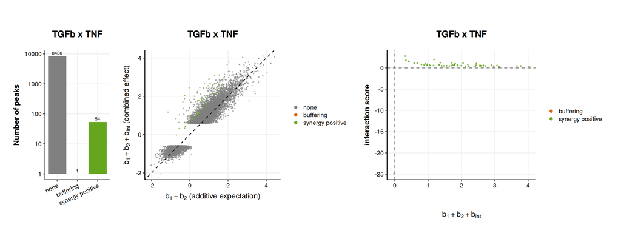

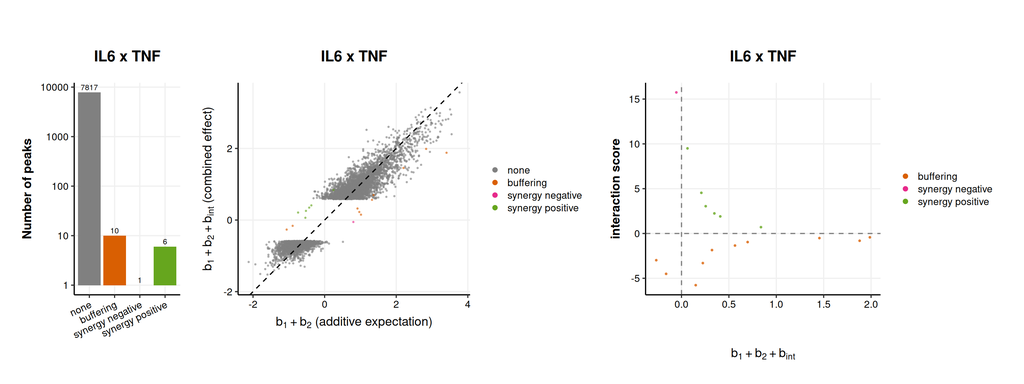

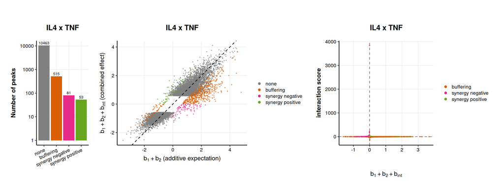

# Heatmaps

Three pairs of heatmaps, one pair per `ligand1`. Columns are the four conditions of that 2 x 2 block — `none_none`, `{ligand1}_none`, `none_TNF`, `{ligand1}_TNF` — in that fixed order; rows are peaks faceted by interaction class. Values are VST-normalized accessibility, z-scored per peak.

For each ligand: `...-all.pdf` keeps every classified peak (four facets, including the additive `none` peaks) and `...-interactions-only.pdf` keeps only the three interaction classes.

```r
n.row.labels <- 5    # peaks labelled per class, by |interaction score| then |lfc_condition|
max.named.rows <- 80 # at or below this many rows every row gets its own name instead

# Colour scale for the heatmap matrix. Values are per-peak z-scores of VST accessibility,
# so the scale is symmetric about 0 and the same for every heatmap below. `heatmap.limit`
# is where the ramp saturates -- lower it to make modest differences more visible, raise it
# to compress them. Replace `heatmap.col` outright with any circlize::colorRamp2() to use a
# different set of colours.
heatmap.limit <- 5
heatmap.col <- colorRamp2(
  seq(-heatmap.limit, heatmap.limit, length.out = 9),
  c("#173c68", "#1c5785", "#166db0", "#a6d1e3", "#ffffff",
    "#f09173", "#d46052", "#b32339", "#690822"))

interaction_heatmap <- function(df, l1, l2 = "TNF", drop.none = FALSE, save = TRUE) {
  conditions <- c("none_none", paste0(l1, "_none"),
                  paste0("none_", l2), paste0(l1, "_", l2))

  cells <- rownames(md)[md$condition %in% conditions]
  md.sub <- md[cells, ]
  md.sub$condition <- factor(as.character(md.sub$condition), levels = conditions)
  md.sub <- md.sub[order(md.sub$condition), ]
  cells <- rownames(md.sub)

  wanted <- if (drop.none) itxn_levels else class_levels
  d <- df %>%
    filter(!is.na(interaction_class), interaction_class %in% wanted,
           name %in% rownames(expr.mtx)) %>%
    mutate(interaction_class = factor(as.character(interaction_class), levels = wanted)) %>%
    arrange(interaction_class, desc(lfc_condition))

  if (nrow(d) == 0) return(NULL)

  # classes with no peaks would otherwise appear as an empty slice and a dead legend key
  d$interaction_class <- droplevels(d$interaction_class)
  keep.levels <- levels(d$interaction_class)

  # Small sets get every row named outright; large ones fall back to `anno_mark`
  # on the top few per class, since 500+ row names are unreadable either way.
  name.all.rows <- nrow(d) <= max.named.rows
  # peaks further than the 50 kb cutoff carry no symbol, so fall back to the peak ID
  # rather than leaving those rows blank
  display.labels <- ifelse(is.na(d$geneSymbol) | d$geneSymbol == "", d$name, d$geneSymbol)

  row.labels <- d %>%
    filter(geneSymbol != "", !is.na(geneSymbol)) %>%
    group_by(interaction_class) %>%
    arrange(desc(abs(interaction_score)), desc(abs(lfc_condition)), .by_group = TRUE) %>%
    slice_head(n = n.row.labels) %>%
    ungroup() %>%
    dplyr::select(feature = name, geneSymbol)

  # the annotation name would sit in the bottom-left corner and collide with the
  # row-slice titles; the legend already names it
  la <- rowAnnotation(
    `interaction class` = d$interaction_class,
    col = setNames(list(interaction_palette[keep.levels]), "interaction class"),
    show_annotation_name = FALSE, show_legend = TRUE)

  ca.col <- list(condition = pal$condition[conditions],
                 ligand1 = pal$ligand1, ligand2 = pal$ligand2)

  ca <- columnAnnotation(df = md.sub[cells, c("condition", "ligand1", "ligand2")],
                         col = ca.col)

  # large sets get sparse `anno_mark` callouts on the right instead of row names
  ra <- if (!name.all.rows && nrow(row.labels) > 0) {
    rowAnnotation(foo = anno_mark(at = match(row.labels$feature, d$name),
                                  labels = row.labels$geneSymbol,
                                  labels_gp = gpar(fontsize = 9)))
  } else NULL

  # z-score each peak across the four conditions of this block
  expr <- t(scale(t(expr.mtx[d$name, cells])))

  ht <- Heatmap(
    matrix = expr, name = "normalized\naccessibility", col = heatmap.col,
    top_annotation = ca, left_annotation = la, right_annotation = ra,
    column_split = md.sub[cells, "condition"], row_split = d$interaction_class,
    cluster_columns = FALSE, cluster_column_slices = FALSE,
    cluster_rows = FALSE, cluster_row_slices = FALSE,
    show_column_names = TRUE, show_row_names = name.all.rows,
    row_labels = display.labels, row_names_side = "right",
    row_names_gp = gpar(fontface = "italic", fontsize = 7),
    column_title_rot = 25, use_raster = TRUE,
    # in the all-classes heatmap the three interaction slices are <5% of the height,
    # so their titles would overprint each other; the colour strip carries the labels
    # wrapped onto two lines so the label fits inside the shorter synergy slices
    row_title = if (drop.none) gsub(" ", "\n", keep.levels) else rep("", length(keep.levels)),
    row_title_gp = gpar(fontsize = 10))

  title <- paste0(l1, " x ", l2, " - ",
                  paste(paste0(levels(d$interaction_class), ": ",
                               as.integer(table(d$interaction_class))),
                        collapse = ", "))

  if (save) {
    suffix <- if (drop.none) "interactions-only" else "all"
    pdf(file.path(PLOT_DIR, attr(df, "dir.itxn"),
                  paste0("heatmap-interaction-classes-", suffix, ".pdf")),
        width = 9, height = if (name.all.rows) max(6, nrow(d) * 0.14 + 3) else 10)
    ComplexHeatmap::draw(ht, column_title = title,
                         column_title_gp = gpar(fontsize = 11))
    invisible(dev.off())
  }
  list(ht = ht, n = nrow(d), title = title)
}
```

## TGFb x TNF - all classified peaks

Saved to `heatmap-interaction-classes-all.pdf`.

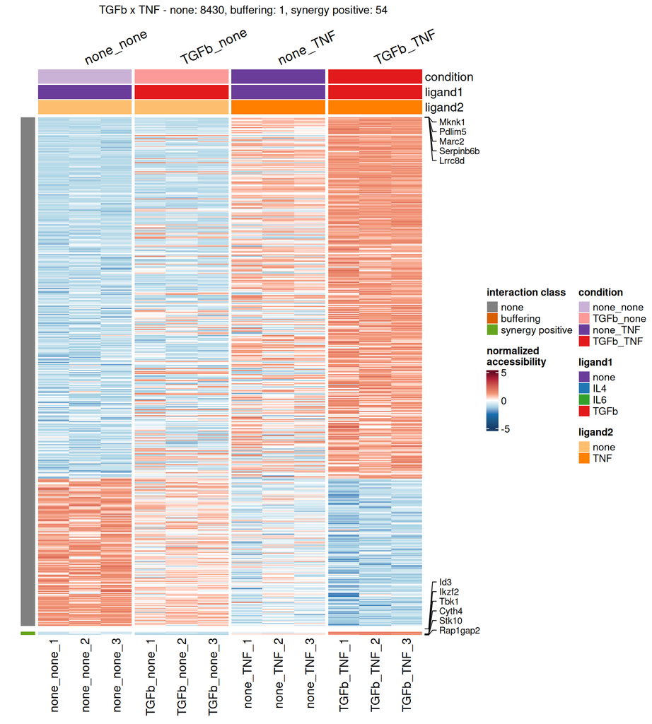

```r
h.tgfb.all <- interaction_heatmap(scored[["TGFb"]], "TGFb", ligand2, drop.none = FALSE)
if (is.null(h.tgfb.all)) {
  message("No peaks in this set.")
} else {
  ComplexHeatmap::draw(h.tgfb.all$ht,
                       column_title = h.tgfb.all$title,
                       column_title_gp = gpar(fontsize = 11))
}
```

## TGFb x TNF - interaction classes only

Saved to `heatmap-interaction-classes-interactions-only.pdf`.

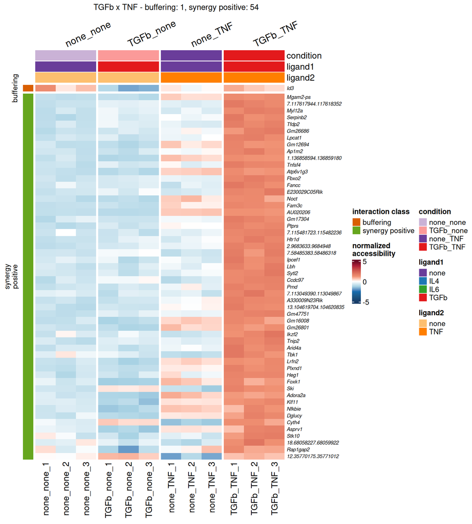

```r
h.tgfb.interactions.only <- interaction_heatmap(scored[["TGFb"]], "TGFb", ligand2, drop.none = TRUE)
if (is.null(h.tgfb.interactions.only)) {
  message("No peaks in this set.")
} else {
  ComplexHeatmap::draw(h.tgfb.interactions.only$ht,
                       column_title = h.tgfb.interactions.only$title,
                       column_title_gp = gpar(fontsize = 11))
}
```

## TGFb x TNF synergy-positive peaks across every condition

The heatmaps above are restricted to the 2 x 2 block the class was called in, so they cannot show whether a TGFb x TNF synergy-positive peak is specific to that pair or also opens under IL4 or IL6. This one keeps the same row set but widens the columns to all eight conditions, z-scoring each peak across all 24 libraries (so the values are not comparable to the block heatmaps above, which z-score within four conditions).

Saved to `heatmap-synergy-positive-all-conditions.pdf` under the TGFb interaction directory.

```r
# Same row set as `interaction_heatmap`, but columns are every condition rather than the
# 2 x 2 block, and rows are never split (a single class is plotted at a time).
class_heatmap_all_conditions <- function(df, l1, cls = "synergy positive", save = TRUE) {
  conditions <- levels(md$condition)

  md.sub <- md[order(md$condition), ]
  cells  <- rownames(md.sub)

  d <- df %>%
    filter(!is.na(interaction_class), interaction_class == cls,
           name %in% rownames(expr.mtx)) %>%
    arrange(desc(lfc_condition))

  if (nrow(d) == 0) return(NULL)

  name.all.rows <- nrow(d) <= max.named.rows
  display.labels <- ifelse(is.na(d$geneSymbol) | d$geneSymbol == "", d$name, d$geneSymbol)

  row.labels <- d %>%
    filter(geneSymbol != "", !is.na(geneSymbol)) %>%
    arrange(desc(abs(interaction_score)), desc(abs(lfc_condition))) %>%
    slice_head(n = n.row.labels) %>%
    dplyr::select(feature = name, geneSymbol)

  ca <- columnAnnotation(
    df  = md.sub[cells, c("condition", "ligand1", "ligand2")],
    col = list(condition = pal$condition[conditions],
               ligand1 = pal$ligand1, ligand2 = pal$ligand2))

  ra <- if (!name.all.rows && nrow(row.labels) > 0) {
    rowAnnotation(foo = anno_mark(at = match(row.labels$feature, d$name),
                                  labels = row.labels$geneSymbol,
                                  labels_gp = gpar(fontsize = 9)))
  } else NULL

  # z-score each peak across all 24 libraries, not just the 2 x 2 block
  expr <- t(scale(t(expr.mtx[d$name, cells])))

  ht <- Heatmap(
    matrix = expr, name = "normalized\naccessibility", col = heatmap.col,
    top_annotation = ca, right_annotation = ra,
    column_split = md.sub[cells, "condition"],
    cluster_columns = FALSE, cluster_column_slices = FALSE,
    cluster_rows = T,
    show_column_names = TRUE, show_row_names = name.all.rows,
    row_labels = display.labels, row_names_side = "right",
    row_names_gp = gpar(fontface = "italic", fontsize = 7),
    column_title_rot = 25, use_raster = TRUE)

  title <- paste0(l1, " x ", ligand2, " ", cls, " peaks (n = ", nrow(d),
                  ") across all conditions")

  if (save) {
    pdf(file.path(PLOT_DIR, attr(df, "dir.itxn"),
                  paste0("heatmap-", gsub(" ", "-", cls), "-all-conditions.pdf")),
        width = 11, height = if (name.all.rows) max(6, nrow(d) * 0.14 + 3) else 10)
    ComplexHeatmap::draw(ht, column_title = title, column_title_gp = gpar(fontsize = 11))
    invisible(dev.off())
  }
  list(ht = ht, n = nrow(d), title = title)
}
```

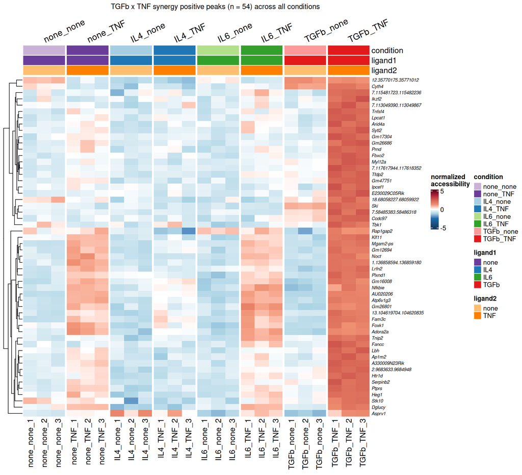

```r
h.tgfb.synpos.all.cond <- class_heatmap_all_conditions(scored[["TGFb"]], "TGFb",
                                                       "synergy positive")
if (is.null(h.tgfb.synpos.all.cond)) {
  message("No peaks in this set.")
} else {
  ComplexHeatmap::draw(h.tgfb.synpos.all.cond$ht,
                       column_title = h.tgfb.synpos.all.cond$title,
                       column_title_gp = gpar(fontsize = 11))
}
```

## IL6 x TNF - all classified peaks

Saved to `heatmap-interaction-classes-all.pdf`.

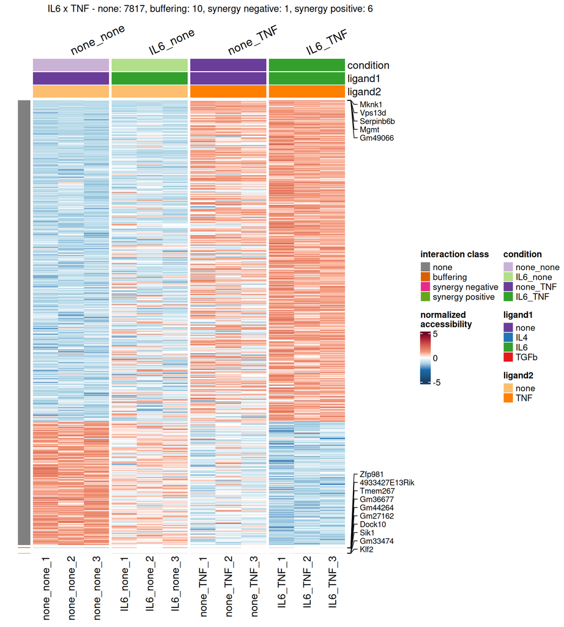

```r
h.il6.all <- interaction_heatmap(scored[["IL6"]], "IL6", ligand2, drop.none = FALSE)
if (is.null(h.il6.all)) {
  message("No peaks in this set.")
} else {
  ComplexHeatmap::draw(h.il6.all$ht,
                       column_title = h.il6.all$title,
                       column_title_gp = gpar(fontsize = 11))
}
```

## IL6 x TNF - interaction classes only

Saved to `heatmap-interaction-classes-interactions-only.pdf`.

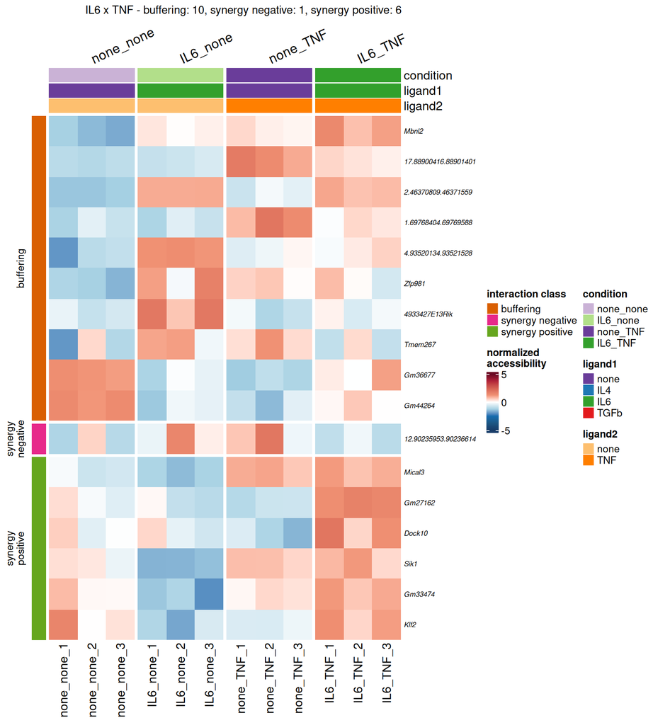

```r
h.il6.interactions.only <- interaction_heatmap(scored[["IL6"]], "IL6", ligand2, drop.none = TRUE)
if (is.null(h.il6.interactions.only)) {
  message("No peaks in this set.")
} else {
  ComplexHeatmap::draw(h.il6.interactions.only$ht,
                       column_title = h.il6.interactions.only$title,
                       column_title_gp = gpar(fontsize = 11))
}
```

## IL4 x TNF - all classified peaks

Saved to `heatmap-interaction-classes-all.pdf`.

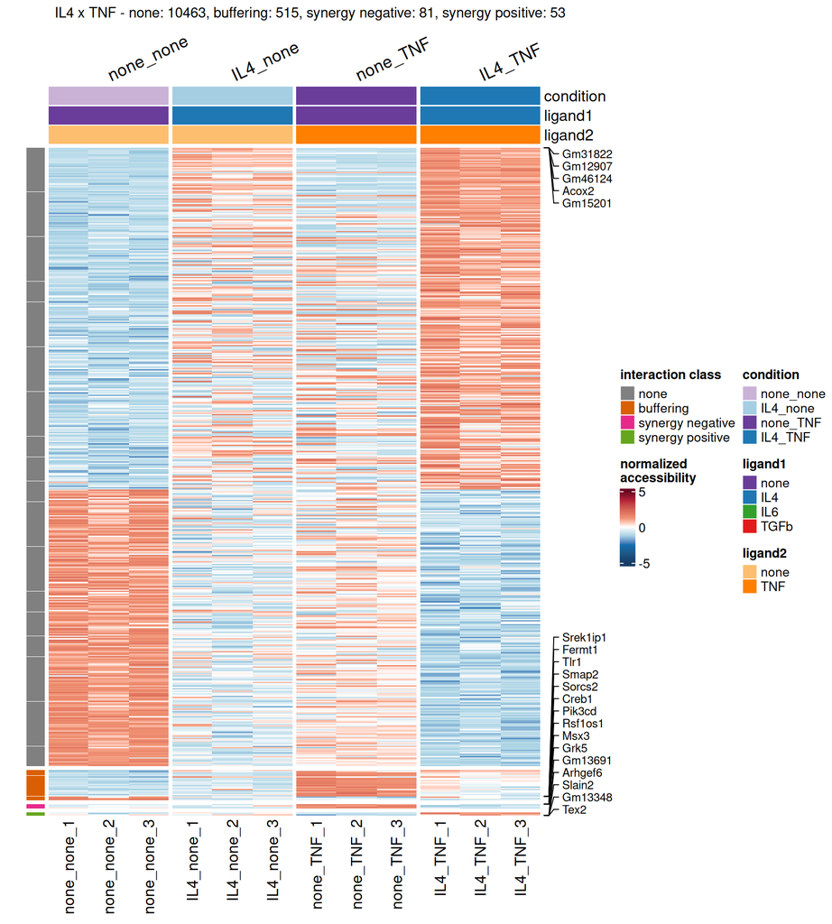

```r
h.il4.all <- interaction_heatmap(scored[["IL4"]], "IL4", ligand2, drop.none = FALSE)
if (is.null(h.il4.all)) {
  message("No peaks in this set.")
} else {
  ComplexHeatmap::draw(h.il4.all$ht,
                       column_title = h.il4.all$title,
                       column_title_gp = gpar(fontsize = 11))
}
```

## IL4 x TNF - interaction classes only

Saved to `heatmap-interaction-classes-interactions-only.pdf`.

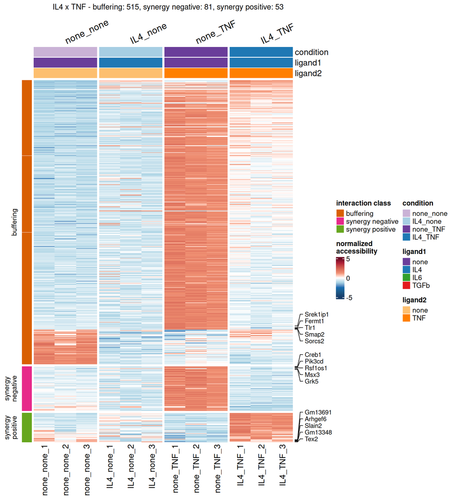

```r
h.il4.interactions.only <- interaction_heatmap(scored[["IL4"]], "IL4", ligand2, drop.none = TRUE)
if (is.null(h.il4.interactions.only)) {
  message("No peaks in this set.")
} else {
  ComplexHeatmap::draw(h.il4.interactions.only$ht,
                       column_title = h.il4.interactions.only$title,
                       column_title_gp = gpar(fontsize = 11))
}
```

# Export

Column schema matches SIG13’s `interactions_scored_v3_glmGamPoi_*.csv`, plus the ATAC-only `geneSymbol` / `distanceToTSS` / `lfc_additive_expected` columns.

```r
walk(scored, function(df) {
  dir.itxn <- attr(df, "dir.itxn")
  out <- df %>%
    dplyr::select(name, interaction, lfc_condition, adj_pval_condition,
                  adj_pval_ligand1, adj_pval_ligand2, lfc_ligand1, lfc_ligand2,
                  lfc_interaction, adj_pval_interaction, lfc_additive_expected,
                  lfc_total_interaction_model, interaction_score, interaction_class,
                  geneSymbol, distanceToTSS)

  write.csv(out, file.path(OUT_DIR, dir.itxn, "interaction-classification.csv"),
            row.names = FALSE)
  write.csv(subset(out, !is.na(interaction_class)),
            file.path(OUT_DIR, dir.itxn, "interaction-classification-sig.csv"),
            row.names = FALSE)
  write.csv(count(out, interaction_class, .drop = FALSE),
            file.path(OUT_DIR, dir.itxn, "interaction-classification-summary.csv"),
            row.names = FALSE)
})
```

# Combined `interScored` table, joined to SIG13 and SIG18 RNA

The three per-ligand tables are concatenated into one `interScored` table covering all `ligand1 x TNF` pairs, and the interaction classes from the two RNA repos — **SIG13** (array perturbation screen, scRNA) and **SIG18** (bulk RNA of polarized CD4 subsets +/- TNF) — are joined onto it by gene symbol so that peaks can be asked to agree with the transcriptional calls.

Both RNA repos score interactions with the same formula used here, at `padj_interaction <= 0.1`.

## Matching SIG16 ATAC to SIG13 RNA

Three things have to be reconciled:

1. **Ligand naming** — TGFb is `TGFB1` in SIG13.
2. **Pair orientation** — SIG13 delivers the two guides in two rounds and scores each order separately, so `IL4_TNF` and `TNF_IL4` are *different rows with their own classes*. Both are kept (`..._ligand1_first`, `..._TNF_first`) and reconciled by **taking the orientation that shows an effect**: a real class beats `none`, `none` beats `NA`, and ties go to the smaller interaction FDR. `rna_orientation_used` records which one supplied the call. This is what makes the TGFB1 arm usable — `TNF_TGFB1` is essentially inert (1 `synergy positive` gene vs 104 for `TGFB1_TNF`), so the informative orientation is the one that gets used.
3. **Gene identity** — the join key is the ChIPseeker nearest gene (`geneSymbol`, blanked beyond 50 kb from a TSS) against SIG13’s `name`. Genes SIG13 never tested — its `0.05filter` keeps only ~8.8k expressed genes — come back `NA`, which is *not* the same as an RNA `none`.

A peak-to-gene join is many-to-one in both directions: one gene can carry several peaks, and one peak is assigned to exactly one nearest gene. Treat a match as “this peak lies near a gene whose transcript shows the same interaction”, not as a validated regulatory link.

```r
SIG13_SCORED <- file.path("/data1/rudenska/EYW/git_projects/SIG13/analysis_outs/glmGamPoi",
                          "interactions_scored_v3_glmGamPoi_0.05filter.csv")

# SIG13 ligand names for the SIG16 ligand1s
rna_ligand <- c(TGFb = "TGFB1", IL6 = "IL6", IL4 = "IL4")

rna_pairs <- tibble(
  ligand1     = rep(names(rna_ligand), each = 2),
  orientation = rep(c("ligand1_first", "TNF_first"), times = length(rna_ligand)),
  interaction = c(rbind(paste0(rna_ligand, "_", ligand2),
                        paste0(ligand2, "_", rna_ligand))))

# 2 = a real interaction call, 1 = tested but additive, 0 = not tested
informativeness <- function(x) dplyr::case_when(is.na(x) ~ 0L, x == "none" ~ 1L, TRUE ~ 2L)

rna <- fread(SIG13_SCORED,
             select = c("name", "interaction", "lfc_condition", "adj_pval_condition",
                        "lfc_interaction", "adj_pval_interaction",
                        "interaction_score", "interaction_class"))
rna <- rna[interaction %in% rna_pairs$interaction]

rna_wide <- as_tibble(rna) %>%
  left_join(rna_pairs, by = "interaction") %>%
  dplyr::select(ligand1, geneSymbol = name, orientation,
                rna_class = interaction_class, rna_score = interaction_score,
                rna_padj_int = adj_pval_interaction, rna_lfc_condition = lfc_condition) %>%
  pivot_wider(names_from = orientation,
              values_from = c(rna_class, rna_score, rna_padj_int, rna_lfc_condition)) %>%
  mutate(
    # rank each orientation by how much it has to say: a real class (2) beats `none` (1),
    # which beats an untested `NA` (0). Ties go to the smaller interaction FDR.
    .rank_first = informativeness(rna_class_ligand1_first),
    .rank_tnf   = informativeness(rna_class_TNF_first),
    .keep_first = .rank_first > .rank_tnf |
                  (.rank_first == .rank_tnf &
                   coalesce(rna_padj_int_ligand1_first, Inf) <=
                   coalesce(rna_padj_int_TNF_first, Inf)),
    rna_orientation_used = dplyr::case_when(
      .rank_first == 0 & .rank_tnf == 0 ~ NA_character_,
      .keep_first ~ "ligand1_first",
      TRUE ~ "TNF_first"),
    rna_interaction_class = if_else(.keep_first, rna_class_ligand1_first, rna_class_TNF_first),
    rna_interaction_score = if_else(.keep_first, rna_score_ligand1_first, rna_score_TNF_first),
    rna_adj_pval_interaction = if_else(.keep_first, rna_padj_int_ligand1_first,
                                       rna_padj_int_TNF_first),
    rna_lfc_condition = if_else(.keep_first, rna_lfc_condition_ligand1_first,
                                rna_lfc_condition_TNF_first)) %>%
  dplyr::select(-starts_with("rna_score_"), -starts_with("rna_padj_int_"),
                -starts_with("rna_lfc_condition_"), -.keep_first, -.rank_first, -.rank_tnf)

cat("SIG13 genes available for the three pairs: ", n_distinct(rna_wide$geneSymbol), "\n", sep = "")
```

```
## SIG13 genes available for the three pairs: 8814
```

## Matching SIG16 ATAC to SIG18

SIG18 scores five arms against TNF: `TGFb`, `Th1`, `Th2`, `Th17` and `iTreg`. Two are used here:

- `TGFb` -> **TGFb**, a like-for-like counterpart of the SIG16 ligand.
- `Th2` -> **IL4**, a *surrogate*: Th2 is an IL4-polarized subset rather than an acute IL4 pulse on naive cells, so the match is on the driving cytokine, not on the cell state.

`IL6` is still left **unmatched** — the nearest arm, `Th17`, is driven by TGFb + IL6 and so confounds the two SIG16 ligands. Edit `sig18_match` below to change any of this.

All five arms are attached as `sig18_class_*` reference columns regardless, so the unused arms are one column lookup away.

Unlike SIG13, SIG18 has no `NA` class: every gene it tested gets a call, so `none` means “tested, no interaction” and `NA` means the gene is absent from SIG18 (or the peak has no symbol).

```r
SIG18_SCORED <- file.path("/data1/rudenska/EYW/git_projects/SIG18/analysis_outs/deg_updated",
                          "res_interaction_scored_SIG18.csv")

# SIG16 ligand1 -> SIG18 condition; NA means "no equivalent perturbation in SIG18"
# IL4 <- Th2 is a surrogate (polarized subset, not an acute IL4 pulse); IL6 has no clean arm
sig18_match <- tibble(ligand1         = c("TGFb", "IL6", "IL4"),
                      sig18_condition = c("TGFb", NA,    "Th2"))

sig18 <- fread(SIG18_SCORED,
               select = c("gene", "ligand1", "lfc_interaction", "padj_interaction",
                          "lfc_total", "interaction_score", "interaction_class")) %>%
  as_tibble() %>%
  dplyr::rename(geneSymbol = gene, sig18_condition = ligand1)

stopifnot(!any(duplicated(sig18[, c("geneSymbol", "sig18_condition")])))

# every SIG18 arm as its own class column, for ad-hoc comparisons
sig18_wide <- sig18 %>%
  dplyr::select(geneSymbol, sig18_condition, interaction_class) %>%
  pivot_wider(names_from = sig18_condition, values_from = interaction_class,
              names_prefix = "sig18_class_")

# the matched arm's full numbers, keyed by the SIG16 ligand1
sig18_matched <- sig18_match %>%
  filter(!is.na(sig18_condition)) %>%
  left_join(sig18, by = "sig18_condition") %>%
  dplyr::select(ligand1, geneSymbol,
                sig18_interaction_class = interaction_class,
                sig18_interaction_score = interaction_score,
                sig18_padj_interaction  = padj_interaction,
                sig18_lfc_total         = lfc_total)

cat("SIG18 genes: ", n_distinct(sig18$geneSymbol),
    " | matched arms: ", paste(na.omit(sig18_match$sig18_condition), collapse = ", "), "\n", sep = "")
```

```
## SIG18 genes: 10167 | matched arms: TGFb, Th2
```

```r
interScored <- imap_dfr(scored, ~ mutate(.x, ligand1 = .y, .after = name)) %>%
  # peaks >50 kb from a TSS carry no symbol and cannot be joined
  left_join(rna_wide,     by = c("ligand1", "geneSymbol")) %>%
  left_join(sig18_wide,   by = "geneSymbol") %>%
  left_join(sig18_matched, by = c("ligand1", "geneSymbol")) %>%
  mutate(
    .atac_sp  = !is.na(interaction_class)       & interaction_class       == "synergy positive",
    .sig13_sp = !is.na(rna_interaction_class)   & rna_interaction_class   == "synergy positive",
    .sig18_sp = !is.na(sig18_interaction_class) & sig18_interaction_class == "synergy positive",
    synergy_positive_both       = .atac_sp & .sig13_sp,   # ATAC + SIG13, as before
    synergy_positive_atac_sig18 = .atac_sp & .sig18_sp,
    synergy_positive_all3       = .atac_sp & .sig13_sp & .sig18_sp) %>%
  dplyr::select(-.atac_sp, -.sig13_sp, -.sig18_sp)

cat(nrow(interScored), " peak x pair rows; ",
    sum(!is.na(interScored$rna_interaction_class)),   " carry a SIG13 call; ",
    sum(!is.na(interScored$sig18_interaction_class)), " carry a matched SIG18 call\n", sep = "")
```

```
## 189654 peak x pair rows; 70340 carry a SIG13 call; 63328 carry a matched SIG18 call
```

## ATAC vs RNA cross-tabulation

These are lookups, not validation. SIG13 and SIG18 are **different systems sampled at different time points** — SIG13 an array perturbation screen read by scRNA, SIG18 bulk RNA of polarized subsets — so the two are not expected to agree with each other, and neither is expected to agree with chromatin. A peak whose nearest gene is called differently by an RNA assay is not evidence that either call is wrong. Use these tables to find candidates, not to arbitrate.

Rows are peaks, not genes, so a gene with several peaks is counted several times. `not tested` means the gene is absent from that RNA repo — below SIG13’s expression filter, or outside SIG18’s gene set — or the peak has no gene within 50 kb. For SIG18 it additionally covers IL6, which has no matched arm.

```r
concordance <- function(col) {
  interScored %>%
    filter(!is.na(interaction_class)) %>%
    mutate(other = fct_na_value_to_level(factor(.data[[col]], levels = class_levels),
                                         "not tested")) %>%
    count(ATAC = interaction_class, other) %>%
    pivot_wider(names_from = other, values_from = n, values_fill = 0)
}
```

SIG13:

```r
concordance("rna_interaction_class")
```

```
## # A tibble: 4 × 6
##   ATAC         none buffering `synergy negative` `synergy positive` `not tested`
##   <fct>       <int>     <int>              <int>              <int>        <int>
## 1 none         6179      1606                845                578        17502
## 2 buffering      60        63                 29                 11          363
## 3 synergy ne…    11        11                  6                  0           54
## 4 synergy po…    34         7                  3                  8           61
```

SIG18 (matched arms: TGFb rows against `TGFb`, IL4 rows against `Th2`; IL6 has no counterpart):

```r
concordance("sig18_interaction_class")
```

```
## # A tibble: 4 × 6
##   ATAC         none buffering `synergy negative` `synergy positive` `not tested`
##   <fct>       <int>     <int>              <int>              <int>        <int>
## 1 none         7018       796                329                328        18239
## 2 buffering     201         5                  1                  1          318
## 3 synergy ne…    38         2                  0                  0           42
## 4 synergy po…    44         5                  1                  5           58
```

Peaks called `synergy positive` by the ATAC and at least one RNA assay. Agreement with *one* assay is the realistic bar here; `all3` is a stricter subset, not a quality threshold:

```r
interScored %>%
  filter(synergy_positive_both | synergy_positive_atac_sig18) %>%
  arrange(desc(synergy_positive_all3), ligand1, desc(abs(interaction_score))) %>%
  dplyr::select(ligand1, geneSymbol, name, distanceToTSS,
                atac_score = interaction_score,
                sig13 = rna_interaction_class, sig13_score = rna_interaction_score,
                sig13_orientation = rna_orientation_used,
                sig18 = sig18_interaction_class, sig18_score = sig18_interaction_score,
                all3 = synergy_positive_all3) %>%
  mutate(across(where(is.numeric), ~ signif(.x, 3)))
```

```
## # A tibble: 12 × 11
##    ligand1 geneSymbol name            distanceToTSS atac_score sig13 sig13_score
##    <chr>   <chr>      <chr>                   <dbl>      <dbl> <chr>       <dbl>
##  1 TGFb    Ap1m2      9.21305241.213…         -2250      0.598 syne…       0.331
##  2 IL4     Adk        14.21112594.21…         36400      5.23  syne…       7.99
##  3 IL4     Usp6nl     2.6391226.6392…        -28700      0.559 syne…       4.27
##  4 TGFb    Ikzf2      1.69731082.697…        -43800      1.23  none        0
##  5 TGFb    Cyth4      15.78607276.78…          1480      1.12  buff…      -8.48
##  6 TGFb    Sytl2      7.90306048.903…          3800      0.759 syne…       1.21
##  7 TGFb    Lpcat1     13.73475261.73…          3510      0.643 none        0
##  8 TGFb    Heg1       16.33707862.33…        -22300      0.631 syne…       0.228
##  9 TGFb    Tfdp2      9.96189309.961…         -6190      0.578 syne…       0.843
## 10 TGFb    Plxnd1     6.115988988.11…          4870      0.565 none        0
## 11 TGFb    Tnfsf4     1.161387203.16…         -7370      0.54  syne…       0.385
## 12 TGFb    Ptprs      17.56443006.56…          3530      0.407 syne…       0.284
## # ℹ 4 more variables: sig13_orientation <chr>, sig18 <chr>, sig18_score <dbl>,
## #   all3 <lgl>
```

## Export

Written next to the DESeq2 results rather than to `analysis_outs/`, because `analysis_outs/interScored_SIG16_ATAC.csv` is the **archived nf-core-consensus-atlas** table with `Interval_NNNNN` peak IDs — a different atlas that must not be overwritten or joined to these.

```r
write.csv(interScored,
          file.path(OUT_DIR, "interScored_SIG16_ATAC_idr-0.05.csv"), row.names = FALSE)
write.csv(subset(interScored, !is.na(interaction_class)),
          file.path(OUT_DIR, "interScored_SIG16_ATAC_idr-0.05_sig.csv"), row.names = FALSE)
```